# Google Data Analytics Capstone - Cyclistic

Annisa. A

26 June 2023

## Introduction

In this case study, I performed data analysis for a fictional bike-share company Cyclistic in order to help them attract more riders. The full guidelines and instructions can be found on this link. The projects followed general data analysis steps and process; **Ask**, **Prepare**, **Process**, **Analyze**, **Share**, and **Act**. The data in this projects use Cyclistic’s historical trip data to analyze and identify trends.

(Note: The datasets have a different name because Cyclistic is a fictional company. For the purposes of this case study, the datasets are appropriate and will enable the analyst to answer the business questions. The data has been made available by Motivate International Inc. under this [licence](https://ride.divvybikes.com/data-license-agreement).)

## I. Ask

### Scenario

*You are a junior data analyst working in the marketing analyst team at Cyclistic, a bike-share company in Chicago. The director of marketing believes the company’s future success depends on maximizing the number of annual memberships. Therefore,your team wants to understand how casual riders and annual members use Cyclistic bikes differently. From these insights,your team will design a new marketing strategy to convert casual riders into annual members. But first, Cyclistic executives must approve your recommendations, so they must be backed up with compelling data insights and professional data visualizations.*

Stakeholder first question to answer:

1. How do annual members and casual riders use Cyclistic bike differently?

**Guiding questions**

- What is the main problem you are trying to solve? The problems i’m trying to solve is how annual members and casual riders use Cyclistic bike differently, what motivates the casual riders to buy annual membership, and how to influence casual riders to be annual members. The main objective is to convert casual riders into annual members.
- How can your insight drive business decision? The insights from these analysis will help the marketing analyst team to design new marketing strategy to convert casual riders into annual members.

**Deliverable**

A clear statement of business task;

*Understand the differents of annual members and casual riders use Cyclistic Share Bike and design the new digital marketing strategy to turn casual riders into annual members.*

## Prepare

This capstone project use data from this [link](https://divvy-tripdata.s3.amazonaws.com/index.html). The data has been made available by Motivate International Inc. under this [licence](https://ride.divvybikes.com/data-license-agreement). The data that used in this project is from June 2022-May 2023.

**Guiding Questions**

- Where is your data located? The data located in this [link](https://divvy-tripdata.s3.amazonaws.com/index.html), kaggle dataset, my personal drive, and cloud.
- How is data organized? The data organized into one folder .csv file and divided by month.
- Are there any issues with bias or credibility in this data? Does your data ROCCC? We assume this dataset is credible because collected from their own resource (first-party data). The data is ROCCC, which is reliable, original, comprehensive, current, and cited.
- How are you addressing licensing, privacy, security, and accessibility? For the purposes of this case study, the datasets are appropriate for answering the business questions. The data has been made available by Motivate International Inc. under this [licence](https://ride.divvybikes.com/data-license-agreement). This is public data, but note that data-privacy issues prohibit you from using riders’ personally identifiable information.
- How did you verify the data’s intergrity? All the data files have consistent and accurate columns name, the data for each column have consistent data type.
- How does it help you to answer questions? By processing and analyzing this datasets we might find the pattern and trend of Cyclistic customers and generate insights for designing new marketing strategy.
- Are there any problem with the data? The data need a further cleaning process and some missing values particularly information for bike stations (start and end).

**Deliverable**

A description all data sources used;

This is public data and has been made available by Motivate International Inc. under this [licence](https://ride.divvybikes.com/data-license-agreement). The data that used in this project is from June 2022-May 2023.

## Process

In this step, the data need to be processed to prepare it before the step of actual analysis. Cleaning the data and make sure of the accuracy, completeness, correctness, and the consistency of the data. Checking the data as much as possible to ensure it’s integrity and avoiding bias, and eciding what tools to use.

**Installing and updating the necessary packages in Rstudio**

```r
library(tidyverse)
library(lubridate)
library(readr)
library (dplyr)
```

**Merge all the csv files into single data frame**

```r
csv_files <- list.files(path="D:/Google Data Analytics/Course 8/Case study Cyclistic Bike Share/All CSV file",
                             pattern = "*.csv", full.names = TRUE)
cyclistic_merged <- do.call(rbind, lapply(csv_files, read.csv))
```

```r
head(cyclistic_merged)
```

|  | ride_id | rideable_type | started_at | ended_at | start_station_name | start_station_id | end_station_name | end_station_id | start_lat | start_lng | end_lat | end_lng | member_casual |
| --- | --- | --- | --- | --- | --- | --- | --- | --- | --- | --- | --- | --- | --- |
| 1 | 600CFD130D0FD2A4 | electric_bike | 2022-06-30 17:27:53 | 2022-06-30 17:35:15 |  |  |  |  | 41.89 | -87.62 | 41.91 | -87.62 | casual |
| 2 | F5E6B5C1682C6464 | electric_bike | 2022-06-30 18:39:52 | 2022-06-30 18:47:28 |  |  |  |  | 41.91 | -87.62 | 41.93 | -87.63 | casual |
| 3 | B6EB6D27BAD771D2 | electric_bike | 2022-06-30 11:49:25 | 2022-06-30 12:02:54 |  |  |  |  | 41.91 | -87.65 | 41.89 | -87.61 | casual |
| 4 | C9C320375DE1D5C6 | electric_bike | 2022-06-30 11:15:25 | 2022-06-30 11:19:43 |  |  |  |  | 41.80 | -87.66 | 41.80 | -87.65 | casual |
| 5 | 56C055851023BE98 | electric_bike | 2022-06-29 23:36:50 | 2022-06-29 23:45:17 |  |  |  |  | 41.91 | -87.63 | 41.93 | -87.64 | casual |
| 6 | B664188E8163D045 | electric_bike | 2022-06-30 16:42:10 | 2022-06-30 16:58:22 |  |  |  |  | 42.03 | -87.71 | 42.06 | -87.73 | casual |

#### Data Cleaning

**Identify if there’s any duplicate with code below using ride_id field**

```r
cyclistic_dups <- duplicated(cyclistic_merged$ride_id)
```

**If there is/are any duplicate(s), removing duplicates of data observation**

```r
cyclistic_no_dups <- cyclistic_merged[!duplicated(cyclistic_merged$ride_id), ]
```

*Note: this dataset does not contain any duplicates.

**Identify and count null value based on ride_id field**

```r
null_ride_id <- sum(is.na(cyclistic_merged$ride_id))
print(null_ride_id)
```

```
[1] 0
```

**Parsing data datetime from ‘chr’ to ‘POSIXct’**

```r
cyclistic_merged$started_at <- as.POSIXct(cyclistic_merged$started_at, format = "%Y-%m-%d %H:%M:%S")
cyclistic_merged$ended_at <- as.POSIXct(cyclistic_merged$ended_at, format = "%Y-%m-%d %H:%M:%S")
```

**Identify consistency of data (started_at > ended_at)**

```r
inconsistent_data_value <- cyclistic_merged[cyclistic_merged$started_at > cyclistic_merged$ended_at, ]
head(inconsistent_data_value)
```

|  | ride_id | rideable_type | started_at | ended_at | start_station_name | start_station_id | end_station_name | end_station_id | start_lat | start_lng | end_lat | end_lng | member_casual |
| --- | --- | --- | --- | --- | --- | --- | --- | --- | --- | --- | --- | --- | --- |
| 126110 | B897BE02B21FA75E | electric_bike | 2022-06-07 19:15:39 | 2022-06-07 17:05:37 |  |  | Kostner Ave & North Ave | 519 | 41.90000 | -87.74000 | 41.91000 | -87.74000 | casual |
| 126533 | 072E947E156D142D | electric_bike | 2022-06-07 19:14:46 | 2022-06-07 17:07:45 | W Armitage Ave & N Sheffield Ave | 20254.0 | W Armitage Ave & N Sheffield Ave | 20254.0 | 41.92000 | -87.65000 | 41.92000 | -87.65000 | casual |
| 278806 | 6A871510E302E8CD | electric_bike | 2022-06-23 19:22:57 | 2022-06-23 19:21:46 |  |  | Green St & Randolph St* | chargingstx3 | 41.88000 | -87.65000 | 41.88360 | -87.64863 | member |
| 301278 | BF114472ABA0289C | electric_bike | 2022-06-07 19:14:47 | 2022-06-07 17:05:42 | Base - 2132 W Hubbard | Hubbard Bike-checking (LBS-WH-TEST) | W Armitage Ave & N Sheffield Ave | 20254.0 | 41.91783 | -87.65336 | 41.92000 | -87.65000 | member |
| 532884 | B3BE8FE661F79405 | electric_bike | 2022-06-07 16:18:37 | 2022-06-07 16:07:28 |  |  | Clinton St & Washington Blvd | WL-012 | 41.88000 | -87.64000 | 41.88338 | -87.64117 | member |
| 568791 | EF3CCF2B05635B96 | electric_bike | 2022-06-07 18:47:01 | 2022-06-07 17:05:41 |  |  |  |  | 41.92000 | -87.72000 | 41.93000 | -87.79000 | casual |

**Removing inconsistent data values**

```r
cyclistic_filtered <- filter(cyclistic_merged, cyclistic_merged$started_at < cyclistic_merged$ended_at )
head(cyclistic_filtered)
```

|  | ride_id | rideable_type | started_at | ended_at | start_station_name | start_station_id | end_station_name | end_station_id | start_lat | start_lng | end_lat | end_lng | member_casual |
| --- | --- | --- | --- | --- | --- | --- | --- | --- | --- | --- | --- | --- | --- |
| 1 | 600CFD130D0FD2A4 | electric_bike | 2022-06-30 17:27:53 | 2022-06-30 17:35:15 |  |  |  |  | 41.89 | -87.62 | 41.91 | -87.62 | casual |
| 2 | F5E6B5C1682C6464 | electric_bike | 2022-06-30 18:39:52 | 2022-06-30 18:47:28 |  |  |  |  | 41.91 | -87.62 | 41.93 | -87.63 | casual |
| 3 | B6EB6D27BAD771D2 | electric_bike | 2022-06-30 11:49:25 | 2022-06-30 12:02:54 |  |  |  |  | 41.91 | -87.65 | 41.89 | -87.61 | casual |
| 4 | C9C320375DE1D5C6 | electric_bike | 2022-06-30 11:15:25 | 2022-06-30 11:19:43 |  |  |  |  | 41.80 | -87.66 | 41.80 | -87.65 | casual |
| 5 | 56C055851023BE98 | electric_bike | 2022-06-29 23:36:50 | 2022-06-29 23:45:17 |  |  |  |  | 41.91 | -87.63 | 41.93 | -87.64 | casual |
| 6 | B664188E8163D045 | electric_bike | 2022-06-30 16:42:10 | 2022-06-30 16:58:22 |  |  |  |  | 42.03 | -87.71 | 42.06 | -87.73 | casual |

#### Transform Data

**Ride duration in minutes**

```r
cyclistic_filtered <- cyclistic_filtered %>%
  mutate(ride_duration_min = as.numeric(cyclistic_filtered$ended_at - cyclistic_filtered$started_at)/60)
```

```r
summary(cyclistic_filtered$ride_duration_min)
```

```
    Min.  1st Qu.   Median     Mean  3rd Qu.     Max.
    0.02     5.58     9.85    18.71    17.62 41387.25
```

**Month and year into one column**

```r
cyclistic_filtered <- cyclistic_filtered %>%
  mutate(month_year= paste(strftime(cyclistic_filtered$started_at, "%b"),
            "/",
            strftime(cyclistic_filtered$started_at, "%Y")))
unique(cyclistic_filtered$month_year)
```

```
 [1] "Jun / 2022" "Jul / 2022" "Aug / 2022" "Sep / 2022" "Oct / 2022" "Nov / 2022"
 [7] "Dec / 2022" "Jan / 2023" "Feb / 2023" "Mar / 2023" "Apr / 2023" "May / 2023"
```

**Date into day**

```r
cyclistic_filtered <- cyclistic_filtered %>%
  mutate(day = paste(strftime(cyclistic_filtered$ended_at, "%a")))
unique(cyclistic_filtered$day)
```

```
[1] "Thu" "Wed" "Mon" "Sun" "Fri" "Sat" "Tue"
```

**Start hour**

```r
cyclistic_filtered <- cyclistic_filtered %>%
  mutate(start_hour = paste(strftime(cyclistic_filtered$started_at, "%H")))
unique(cyclistic_filtered$start_hour)
```

```
 [1] "17" "18" "11" "23" "16" "12" "10" "08" "03" "15" "13" "00" "19" "01" "20"
[16] "02" "09" "21" "07" "05" "22" "14" "04" "06"
```

**Inspect and verify the dataset**

```r
summary(cyclistic_filtered)
```

```
   ride_id          rideable_type        started_at
 Length:5828463     Length:5828463     Min.   :2022-06-01 00:00:04.00
 Class :character   Class :character   1st Qu.:2022-07-27 14:53:43.00
 Mode  :character   Mode  :character   Median :2022-09-23 07:55:42.00
                                       Mean   :2022-10-28 01:02:05.01
                                       3rd Qu.:2023-02-05 15:35:42.00
                                       Max.   :2023-05-31 23:59:58.00

    ended_at                      start_station_name start_station_id
 Min.   :2022-06-01 00:02:38.00   Length:5828463     Length:5828463
 1st Qu.:2022-07-27 15:14:32.50   Class :character   Class :character
 Median :2022-09-23 08:13:54.00   Mode  :character   Mode  :character
 Mean   :2022-10-28 01:20:47.88
 3rd Qu.:2023-02-05 15:51:28.50
 Max.   :2023-06-07 23:04:26.00

 end_station_name   end_station_id       start_lat       start_lng
 Length:5828463     Length:5828463     Min.   :41.64   Min.   :-87.87
 Class :character   Class :character   1st Qu.:41.88   1st Qu.:-87.66
 Mode  :character   Mode  :character   Median :41.90   Median :-87.64
                                       Mean   :41.90   Mean   :-87.65
                                       3rd Qu.:41.93   3rd Qu.:-87.63
                                       Max.   :42.07   Max.   :-87.52

    end_lat         end_lng       member_casual      ride_duration_min
 Min.   : 0.00   Min.   :-88.11   Length:5828463     Min.   :    0.02
 1st Qu.:41.88   1st Qu.:-87.66   Class :character   1st Qu.:    5.58
 Median :41.90   Median :-87.64   Mode  :character   Median :    9.85
 Mean   :41.90   Mean   :-87.65                      Mean   :   18.71
 3rd Qu.:41.93   3rd Qu.:-87.63                      3rd Qu.:   17.62
 Max.   :42.37   Max.   :  0.00                      Max.   :41387.25
 NA's   :5961    NA's   :5961
  month_year            day             start_hour
 Length:5828463     Length:5828463     Length:5828463
 Class :character   Class :character   Class :character
 Mode  :character   Mode  :character   Mode  :character
```

**Save clean dataset into .csv file**

```r
write.csv(cyclistic_filtered, file= "cyclistic_clean.csv")
```

**Guiding Questions**

- What tools are you choosing and why? For this analysis project I choose to use Rstudio to process, analyze, and share the data, and tableu for creating additional and more comprehensive visualization.
- Have you ensured the data’s integrity? Yes, the integrity of data is important for realiable analysis.
- What steps have you taken to ensure that your data is clean? The steps as explained in the cleaning process code below.
- How can you verify that your data is clean and ready to analyze? It’s verification process done in R by comparing the pre-cleaned dataset and cleaned dataset.
- Have you documented your cleaning process so you can review and share those result? Yes, I cleaned the dataset using RStudio so all the process recorded and documented.

**Deliverable**

All the documentation of the cleaning and manipulation of the dataset.

## Analyze and Share

The clean dataset will be analyzed in this step. The visualizations also will be shared in this step.

**Update ggplot2**

```r
library(ggplot2)
cyclistic_clean <- cyclistic_filtered
head(cyclistic_clean)
```

|  | ride_id | rideable_type | started_at | ended_at | start_station_name | start_station_id | end_station_name | end_station_id | start_lat | start_lng | end_lat | end_lng | member_casual | ride_duration_min | month_year | day | start_hour |
| --- | --- | --- | --- | --- | --- | --- | --- | --- | --- | --- | --- | --- | --- | --- | --- | --- | --- |
| 1 | 600CFD130D0FD2A4 | electric_bike | 2022-06-30 17:27:53 | 2022-06-30 17:35:15 |  |  |  |  | 41.89 | -87.62 | 41.91 | -87.62 | casual | 7.366667 | Jun / 2022 | Thu | 17 |
| 2 | F5E6B5C1682C6464 | electric_bike | 2022-06-30 18:39:52 | 2022-06-30 18:47:28 |  |  |  |  | 41.91 | -87.62 | 41.93 | -87.63 | casual | 7.600000 | Jun / 2022 | Thu | 18 |
| 3 | B6EB6D27BAD771D2 | electric_bike | 2022-06-30 11:49:25 | 2022-06-30 12:02:54 |  |  |  |  | 41.91 | -87.65 | 41.89 | -87.61 | casual | 13.483333 | Jun / 2022 | Thu | 11 |
| 4 | C9C320375DE1D5C6 | electric_bike | 2022-06-30 11:15:25 | 2022-06-30 11:19:43 |  |  |  |  | 41.80 | -87.66 | 41.80 | -87.65 | casual | 4.300000 | Jun / 2022 | Thu | 11 |
| 5 | 56C055851023BE98 | electric_bike | 2022-06-29 23:36:50 | 2022-06-29 23:45:17 |  |  |  |  | 41.91 | -87.63 | 41.93 | -87.64 | casual | 8.450000 | Jun / 2022 | Wed | 23 |
| 6 | B664188E8163D045 | electric_bike | 2022-06-30 16:42:10 | 2022-06-30 16:58:22 |  |  |  |  | 42.03 | -87.71 | 42.06 | -87.73 | casual | 16.200000 | Jun / 2022 | Thu | 16 |

```r
fig <- function(width, heigth){options(repr.plot.width = width, repr.plot.height = heigth)}
```

**Casual vs Member Distribution**

```r
cyclistic_clean %>% group_by(member_casual) %>%
  summarise(count= length(ride_id), '%' = (length(ride_id)/nrow(cyclistic_clean))* 100)
```

| member_casual | count | % |
| --- | --- | --- |
| casual | 2311814 | 39.66421 |
| member | 3516649 | 60.33579 |

**Casual vs Member Distribution Chart**

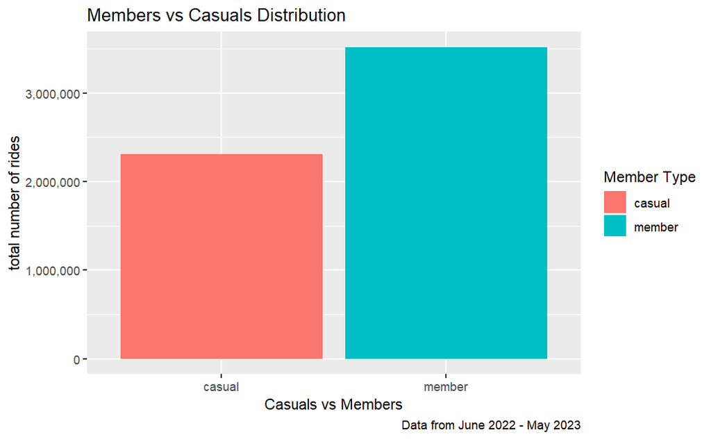

```r
ggplot(data = cyclistic_clean) +
  geom_bar(mapping=aes(x=member_casual, fill=member_casual)) +  scale_y_continuous(labels = scales::comma)+
  labs(title = "Members vs Casuals Distribution", fill="Member Type", x= "Casuals vs Members", y="total number of rides",
       caption = "Data from June 2022 - May 2023")
```

Key points:

- Annual members distribution and percentation are bigger than casual riders.
- Around 39,7% casual riders contribute to number of rides from period of June 2022 to May 2023.

**Member vs Casual Monthly Distribution**

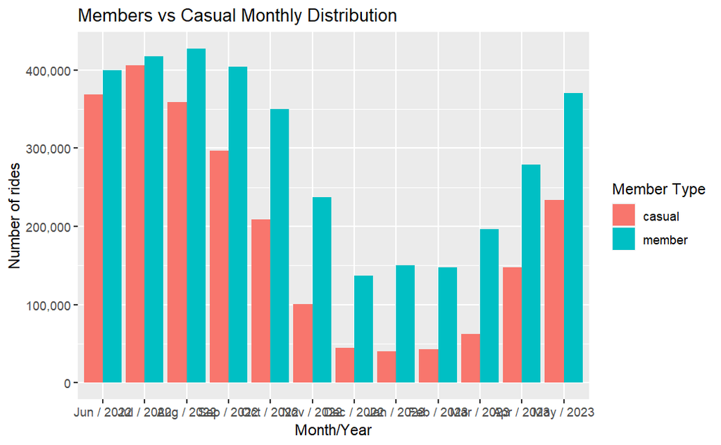

```r
fig(20,7)
my <- factor(cyclistic_clean$month_year, levels=unique(cyclistic_clean$month_year))
ggplot(data=cyclistic_clean) +
  geom_bar(mapping=aes(x=my, fill=member_casual), position = "dodge")+scale_y_continuous(labels = scales::comma)+
  labs(title="Members vs Casual Monthly Distribution", fill="Member Type", y="Number of rides", x="Month/Year")
```

**Data Points Distribution by Month**

```r
cyclistic_clean %>% group_by(month_year) %>%
  summarise(count= length(ride_id), '%' = (length(ride_id)/nrow(cyclistic_clean))* 100)
```

| month_year | count | % |
| --- | --- | --- |
| Apr / 2023 | 426554 | 7.318465 |
| Aug / 2022 | 785855 | 13.483057 |
| Dec / 2022 | 181792 | 3.119038 |
| Feb / 2023 | 190436 | 3.267345 |
| Jan / 2023 | 190293 | 3.264892 |
| Jul / 2022 | 823416 | 14.127498 |
| Jun / 2022 | 769138 | 13.196241 |
| Mar / 2023 | 258659 | 4.437860 |
| May / 2023 | 604756 | 10.375909 |
| Nov / 2022 | 337677 | 5.793586 |

[output cut: 2 more lines]

Key points:

- From November 2022 to February 2023 bike usage dropped sharply. This is probably caused by the winter season and temperature drop.
- The highest data points(number of rides) comes from July 2022, and the lowest is in December 2022.
- Riders, both members and casual typically use Cyclistic higher during summer season (June - September 2022).

**Member vs Casual Weekly Distribution**

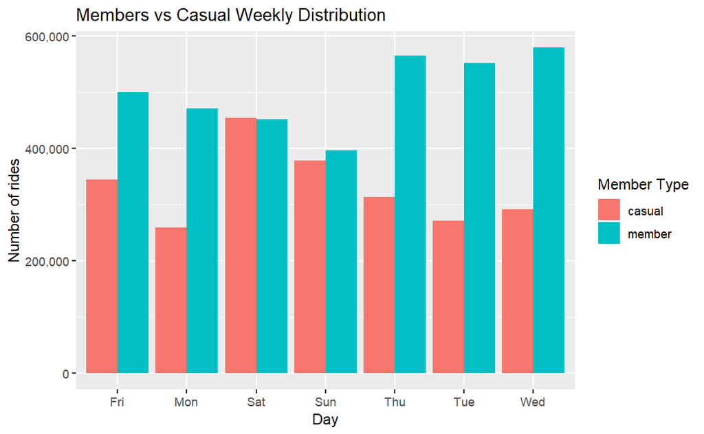

```r
ggplot(data=cyclistic_clean) +
  geom_bar(mapping=aes(x=day, fill=member_casual), position = "dodge")+scale_y_continuous(labels = scales::comma)+
  labs(title="Members vs Casual Weekly Distribution", fill="Member Type", y="Number of rides", x="Day")
```

Key points:

- Casual riders tend to be lower during weekday and higher on the weekend.
- Annual members higher in weekday especially on Tuesday, Wednesday, and Thursday.

**Hour by the day**

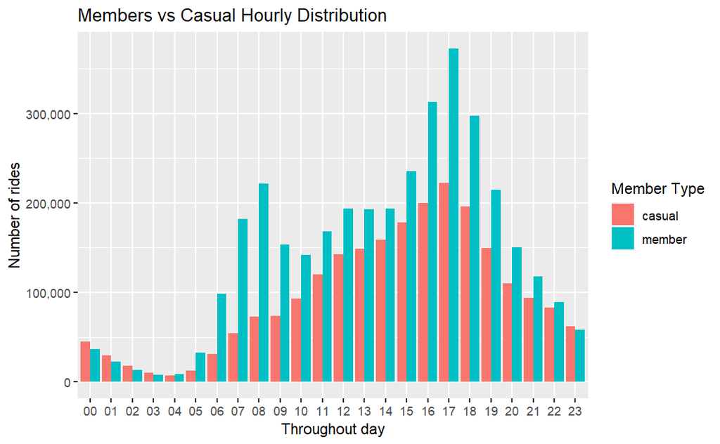

```r
ggplot(data=cyclistic_clean) +
  geom_bar(mapping=aes(x=start_hour, fill=member_casual), position = "dodge")+scale_y_continuous(labels = scales::comma)+
  labs(title="Members vs Casual Hourly Distribution", fill="Member Type", y="Number of rides", x="Throughout day")
```

Key points:

- Throughout the day, both annual members and casual riders use more Cyclistic service during the afternoon (12pm - 19pm).
- In the morning from 6am-9am, there’s an increase for annual members using Cyclistic service.
- 6am-9am and 4pm-6pm are typical rush hours in Chicago.

**Hourly distribution throughout the week**

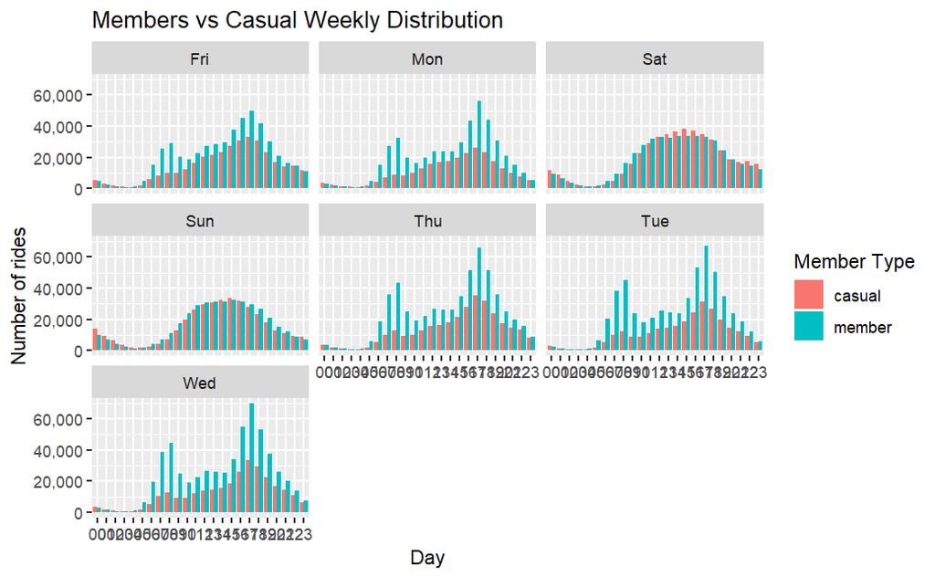

```r
ggplot(data=cyclistic_clean) +
  geom_bar(mapping=aes(x=start_hour, fill=member_casual), position = "dodge")+scale_y_continuous(labels = scales::comma)+
  labs(title="Members vs Casual Weekly Distribution", fill="Member Type", y="Number of rides", x="Day")+
  facet_wrap(~day)
```

Key point:

- On Saturday and Sunday, both annual members and casual riders use Cyclistic proportionally.
- On Monday to Friday members use Cyclistic consistently high.

**Average Ride Duration by Member Type**

```r
cyclistic_clean %>% group_by(member_casual) %>%
  summarise(mean = mean(ride_duration_min))
```

| member_casual | mean |
| --- | --- |
| casual | 28.21166 |
| member | 12.47079 |

Key point:

- The average ride duration for casual riders is bigger than annual members.

**Bike Type**

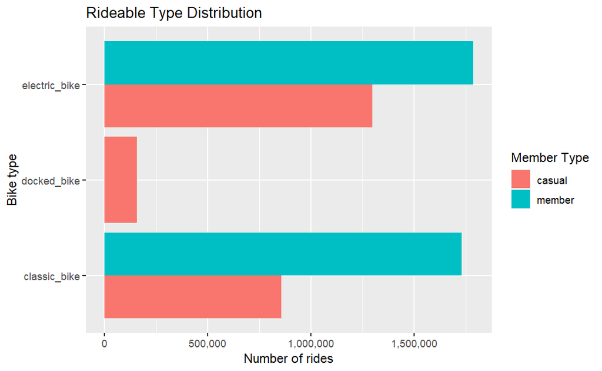

```r
ggplot(data=cyclistic_clean) +
  geom_bar(mapping=aes(x=rideable_type, fill=member_casual), position = "dodge") +
  scale_y_continuous(labels = scales::comma)+
  labs(title="Rideable Type Distribution", fill="Member Type", y="Number of rides", x="Bike type")+
  coord_flip()
```

```r
cyclistic_clean %>% group_by(rideable_type, member_casual) %>%
  summarise(count= length(ride_id), '%' = (length(ride_id)/nrow(cyclistic_clean))* 100)
```

| rideable_type | member_casual | count | % |
| --- | --- | --- | --- |
| classic_bike | casual | 857721 | 14.71608 |
| classic_bike | member | 1730592 | 29.69208 |
| docked_bike | casual | 157196 | 2.69704 |
| electric_bike | casual | 1296897 | 22.25110 |
| electric_bike | member | 1786057 | 30.64370 |

Key Point:

- Annual members prefer classic bikes and electric bikes.
- Docked bike use only a few by casual riders around 2,7%.

**Popular Station Member vs Casual**

- **Start Station**

```r
annual_member_df <- filter(cyclistic_clean, member_casual=="member")
casual_df <- filter(cyclistic_clean, member_casual=="casual")
as_tibble(count(annual_member_df, start_station_name,sort= TRUE))
```

| start_station_name | n |
| --- | --- |
|  | 490417 |
| Kingsbury St & Kinzie St | 25283 |
| Clark St & Elm St | 23238 |
| Clinton St & Washington Blvd | 22195 |
| Wells St & Concord Ln | 21859 |
| University Ave & 57th St | 21487 |
| Loomis St & Lexington St | 20862 |
| Ellis Ave & 60th St | 20460 |
| Wells St & Elm St | 19747 |
| Clinton St & Madison St | 19550 |

[output cut: 990 more lines]

```r
as_tibble(count(casual_df, start_station_name, sort= TRUE))
```

| start_station_name | n |
| --- | --- |
|  | 344094 |
| Streeter Dr & Grand Ave | 55765 |
| DuSable Lake Shore Dr & Monroe St | 31611 |
| Michigan Ave & Oak St | 24726 |
| Millennium Park | 24550 |
| DuSable Lake Shore Dr & North Blvd | 23062 |
| Shedd Aquarium | 19814 |
| Theater on the Lake | 18049 |
| Wells St & Concord Ln | 15800 |
| Dusable Harbor | 14234 |

[output cut: 990 more lines]

- **End Station**

```r
as_tibble(count(annual_member_df, end_station_name, sort=TRUE))
```

| end_station_name | n |
| --- | --- |
|  | 487594 |
| Kingsbury St & Kinzie St | 25256 |
| Clark St & Elm St | 23492 |
| Clinton St & Washington Blvd | 23213 |
| Wells St & Concord Ln | 22693 |
| University Ave & 57th St | 21881 |
| Loomis St & Lexington St | 21082 |
| Clinton St & Madison St | 20443 |
| Ellis Ave & 60th St | 20233 |
| Wells St & Elm St | 19599 |

[output cut: 990 more lines]

```r
as_tibble(count(casual_df, end_station_name, sort=TRUE))
```

| end_station_name | n |
| --- | --- |
|  | 403961 |
| Streeter Dr & Grand Ave | 58031 |
| DuSable Lake Shore Dr & Monroe St | 28964 |
| Millennium Park | 26139 |
| Michigan Ave & Oak St | 25855 |
| DuSable Lake Shore Dr & North Blvd | 25359 |
| Theater on the Lake | 19034 |
| Shedd Aquarium | 17793 |
| Wells St & Concord Ln | 15181 |
| Clark St & Armitage Ave | 13484 |

[output cut: 990 more lines]

Key point:

- Both start and end station for annual members relatively popular in the same area. So do casual riders also have both start and end station similarly.
- Popular start and end stations for casual members mostly located in and/or around tourist attraction areas or open public spaces.

**Guiding Questions**

- How should you organize your data to perform analysis on it? The data that has been cleaned, saved into .csv format file and will be analyzed in Rstudio.
- Has your data been properly formatted? All the data in the columns has been properly formatted.
- What surprises did you discover from the data? Annual members distribution are larger than casuals.
- What trends or relationship did you find in the data? The average ride duration between members and casuals. Annual members tend to ride for shorter time.
- Were you able to answer the question of how annual members and casual riders use Cyclistic bikes differently? Yes
- What story does your data tell? Annual members distribution is bigger than casual riders. Annual members use Cyclistic bikes usually on weekday during rush hours.
- How do your findings relate to your original question? The initial question from this analysis is *How do annual members and casual riders use Cyclistic bike differently* and the all key findings compare the usage of Cyclistic service from both members and casual riders.
- Who is your audience? What is the best way to communicate with them? My audiences are Cyclistic marketing team analytics and director of marketing Lily Moreno. The best way to communicate my findings are through slide presentations.
- Can your data visualization help you share your findings? Yes, the findings mostly through data visualization.
- Is your presentation accessible to your audience? Yes

**Deliverable**

**The summary of the analysis:**

- Annual members distribution and percentation are bigger than casual riders.
- Around 39,7% casual riders contribute to number of rides from period of June 2022 to May 2023.
- From November 2022 to February 2023 bike usage dropped sharply. This is probably caused by the winter season and temperature drop.
- The highest data points(number of rides) comes from July 2022, and the lowest is in December 2022.
- Riders, both members and casual typically use Cyclistic higher during summer season (June - September 2022).
- Casual riders tend to be lower during weekday and higher on the weekend.
- Annual members higher in weekday especially on Tuesday, Wednesday, and Thursday.
- Throughout the day, both annual members and casual riders use more Cyclistic service during the afternoon (12pm - 19pm).
- In the morning from 6am-9am, there’s an increase for annual members using Cyclistic service.
- 6am-9am and 4pm-6pm are typical rush hours in Chicago.
- On Saturday and Sunday, both annual members and casual riders use Cyclistic proportionally.
- On Monday to Friday members use Cyclistic consistently high.
- The average ride duration for casual riders is bigger than annual members.
- Annual members prefer classic bikes and electric bikes.
- Docked bike use only a few by casual riders around 2,7%.
- Both start and end station for annual members relatively popular in the same area. So do casual riders also have both start and end station similarly.
- Popular start and end stations for casual members mostly located in and/or around tourist attraction areas or open public spaces.

**Supporting visualizations as above**

## Act

**Conclusion**

Based on my analysis, findings, and observation;

A. Casual members consist mostly of tourists or people who wish to have recreation and leisure either in the weekend and/or during summertime.

B. Annual members are usually people who commute daily for work or schools/colleges, as they consistently use the Cyclistic service during weekday and higher in rush hours.

C. Even though the annual members contribute higher to the overall number of rides, but the average ride duration for casual riders is higher. This is probably caused by 2 different possibilities according to dataset; 1) because casual members use the bike mostly for recreation or leisures so they tend to use the bike longer than annual members who mostly use it for daily commuting, 2) some casual riders (single-ride passes and full-day passes) use the bike more than as they should (possibility of exploitation) as some example shows that they don’t have end station data point.

```r
cyclistic_exploit <- filter(cyclistic_clean, cyclistic_clean$ride_duration_min > 1440 )
count(cyclistic_exploit, member_casual)
```

| member_casual | n |
| --- | --- |
| casual | 4500 |
| member | 785 |

**Deliverables**

**Recommendations**

A. Increase the pricing for single-ride passes and full-day passes especially during summer, weekend, and/or holiday season (high demand period). Give discounts during winter season.

B. Create campaign and advertisements to promote the benefits of annual membership over single-ride passes and full-day passes, by focusing in the popular stations for casual riders.

C. Enforcing location-based promotions featuring search engine like Google and Google Maps, and also social media like Facebook and Instagram.

**Additional Remarks**

- It would be nice if the data points for start and end station names were mostly available.